# Tablas de Escovid19data

@numeroteca

2020-09-23

Un análisis automatizado de la base de datos por provincias de esCOVID19data en España. Puedes acceder a todos los datos en el repositorio https://github.com/montera34/escovid19data

Puedes ver más visualizaciones en esta web https://lab.montera34.com/covid19/provincias.html

El código .Rmd para generar este informe [está disponile](https://code.montera34.com/numeroteca/covid19/-/blob/master/reports/tablas-escovid19data.Rmd).

- Casos. Incidencia acumulada
  - IA7 por provincia (últimos días)
  - IA7 por provincia (periodo completo)
  - IA14 por provincia (periodo completo)
  - IA7 por CCAA
  - IA14 por CCAA
- Hostpitalizados
- UCI
- Fallecidos

Para ver más tablas de este tipo puedes ver la cuenta de [@ngbpadel2](https://twitter.com/ngbpadel2/) que publica cada día.

# Casos. Incidencia acumulada

## IA7 por provincia (últimos días)

Incidencia acumulada 7 días por 100.000 habitantes. Casos PCR+. Datos de Escovid19data recopilados de las CCAA.

| province | 08-24 | 08-25 | 08-26 | 08-27 | 08-28 | 08-29 | 08-30 | 08-31 | 09-01 | 09-02 | 09-03 | 09-04 | 09-05 | 09-06 | 09-07 | 09-08 | 09-09 | 09-10 | 09-11 | 09-12 | 09-13 | 09-14 | 09-15 | 09-16 | 09-17 | 09-18 | 09-19 | 09-20 | 09-21 | … |
| --- | --- | --- | --- | --- | --- | --- | --- | --- | --- | --- | --- | --- | --- | --- | --- | --- | --- | --- | --- | --- | --- | --- | --- | --- | --- | --- | --- | --- | --- | --- |
| Albacete | 102 | 145 | 134 | 128 | 140 |  |  | 175 | 178 | 182 | 197 | 202 |  |  | 199 | 160 | 150 | 141 | 139 |  |  | 115 | 117 | 124 | 134 | 125 |  |  | 154 | … |
| Alicante/Alacant | 42 | 44 | 50 | 51 | 56 | 56 |  | 61 | 62 | 59 | 64 | 67 | 71 |  | 68 | 67 | 72 | 71 | 75 | 71 |  | 72 | 79 | 82 | 84 | 77 | 81 |  | 81 | … |
| Almería | 121 | 128 | 128 | 132 | 137 | 140 | 136 | 124 | 139 | 145 | 146 | 146 | 140 | 140 | 145 | 139 | 129 | 132 | 123 | 126 | 122 | 112 | 102 | 97 | 97 | 102 | 93 | 95 | 100 | … |
| Araba/Álava | 199 | 202 | 207 | 198 | 195 | 194 | 193 | 203 | 201 | 178 | 186 | 185 | 177 | 180 | 161 | 163 | 176 | 161 | 164 | 159 | 158 | 158 | 142 | 153 | 157 | 146 | 139 | 152 | 160 | … |
| Asturias | 22 | 23 | 25 | 24 | 25 | 26 | 27 | 25 | 23 | 24 | 25 |  |  | 35 | 33 | 37 | 34 | 34 |  |  | 36 | 39 | 40 | 45 | 50 |  |  | 57 | 58 | … |
| Ávila | 122 | 138 | 154 | 158 | 137 | 137 | 166 | 164 | 140 | 132 | 122 | 133 | 139 | 143 | 148 | 163 | 167 | 180 | 159 | 165 | 147 | 164 | 156 | 152 | 144 | 180 | 159 | 186 | 173 | … |
| Badajoz | 46 | 45 | 45 | 51 | 56 | 59 | 67 | 75 | 76 | 80 | 87 | 96 | 92 | 92 | 91 | 95 | 98 | 97 | 93 | 116 | 120 | 129 | 137 | 145 | 150 | 170 | 155 | 156 | 153 | … |
| Balears, Illes | 108 | 167 | 177 | 206 | 201 |  |  | 215 | 151 | 150 | 130 | 134 |  |  | 116 | 128 | 128 | 135 | 134 |  |  |  |  |  |  |  |  |  |  | … |
| Barcelona | 100 | 101 | 105 | 104 | 104 | 105 | 105 | 105 | 105 | 100 | 99 | 101 | 102 | 102 | 100 | 98 | 99 | 100 | 86 | 85 | 84 | 85 | 86 | 87 | 84 | 96 | 97 | 98 | 95 | … |
| Bizkaia | 202 | 206 | 202 | 202 | 226 | 224 | 213 | 206 | 196 | 199 | 192 | 173 | 170 | 189 | 191 | 197 | 195 | 191 | 187 | 181 | 167 | 163 | 156 | 149 | 142 | 134 | 131 | 133 | 133 | … |

[output cut: 42 more lines]

Nota: Galicia incluye algunos casos que son por anticuerpos en su serie, pero al no disponer de una serie con solo casos PCR+ se usa la de casos acumulados. Ver wiki https://github.com/montera34/escovid19data/wiki#informaci%C3%B3n-obtenida-a-partir-del-4-de-junio

## IA7 por provincia, periodo completo

Incidencia acumulada 7 días por 100.000 habitantes. Casos PCR+. Datos de los miércoles. Datos de Escovid19data recopilados de las CCAA.

| province | 03-11 | 03-18 | 03-25 | 04-01 | 04-08 | 04-15 | 04-22 | 04-29 | 05-06 | 05-13 | 05-20 | 05-27 | 06-03 | 06-10 | 06-17 | 06-24 | 07-01 | 07-08 | 07-15 | 07-22 | 07-29 | 08-05 | 08-12 | 08-19 | 08-26 | 09-02 | 09-09 | 09-16 | provincia |
| --- | --- | --- | --- | --- | --- | --- | --- | --- | --- | --- | --- | --- | --- | --- | --- | --- | --- | --- | --- | --- | --- | --- | --- | --- | --- | --- | --- | --- | --- |
| Albacete |  |  |  |  |  |  |  |  |  |  |  | 9 | 17 | 7 | 4 | 4 | 7 | 7 | 4 | 11 | 5 | 13 | 65 | 85 | 134 | 182 | 150 | 124 | Albacete |
| Alicante/Alacant |  |  |  |  |  |  |  |  |  |  |  | 3 | 3 | 0 | 0 | 1 | 1 | 1 | 1 | 6 | 14 | 19 | 23 | 35 | 50 | 59 | 72 | 82 | Alicante/Alacant |
| Almería |  |  |  |  |  |  |  |  |  | 2 | 1 | 1 | 2 | 2 | 0 | 0 | 2 | 3 | 15 | 34 | 28 | 59 | 90 | 121 | 128 | 145 | 129 | 97 | Almería |
| Araba/Álava |  |  |  |  |  |  |  |  |  |  |  | 4 | 4 | 87 | 5 | 6 | 4 | 8 | 8 | 15 | 28 | 77 | 117 | 201 | 207 | 178 | 176 | 153 | Araba/Álava |
| Asturias | 3 | 27 | 57 | 53 | 33 | 33 | 13 | 5 | 3 | 3 | 2 | 4 | 0 | 1 | 0 | 0 | 0 | 0 | 0 | 1 | 5 | 11 | 15 | 16 | 25 | 24 | 34 | 45 | Asturias |
| Ávila |  |  |  |  |  |  |  |  |  |  |  | 27 | 30 | 16 | 5 | 11 | 9 | 2 | 4 | 1 | 1 | 6 | 27 | 53 | 154 | 132 | 167 | 152 | Ávila |
| Badajoz |  |  |  |  |  |  |  |  | 5 | 3 | 2 | 1 | 0 | 0 | 1 | 1 | 2 | 5 | 19 | 7 | 4 | 16 | 21 | 32 | 45 | 80 | 98 | 145 | Badajoz |
| Balears, Illes |  |  |  |  |  |  |  |  |  |  |  |  |  |  |  |  |  | 2 | 3 | 5 | 9 | 35 | 83 | 98 | 177 | 150 | 128 |  | Balears, Illes |
| Barcelona | 3 | 59 | 155 | 177 | 120 | 99 | 97 | 44 | 21 | 19 | 18 | 21 | 11 | 9 | 6 | 5 | 7 | 12 | 36 | 74 | 92 | 91 | 94 | 94 | 105 | 100 | 99 | 87 | Barcelona |
| Bizkaia |  |  |  |  |  |  |  |  |  |  |  | 4 | 2 | 18 | 4 | 3 | 1 | 3 | 7 | 38 | 52 | 88 | 159 | 171 | 202 | 199 | 195 | 149 | Bizkaia |

[output cut: 42 more lines]

Nota: Galicia incluye algunos casos que son por anticuerpos en su serie, pero al no disponer de una serie con solo casos PCR+ se usa la de casos acumulados. Ver wiki https://github.com/montera34/escovid19data/wiki#informaci%C3%B3n-obtenida-a-partir-del-4-de-junio

## IA14 por provincia, periodo completo

Incidencia acumulada 14 días por 100.000 habitantes. Casos PCR+. Datos de los miércoles. Datos de Escovid19data recopilados de las CCAA.

| province | 03-11 | 03-18 | 03-25 | 04-01 | 04-08 | 04-15 | 04-22 | 04-29 | 05-06 | 05-13 | 05-20 | 05-27 | 06-03 | 06-10 | 06-17 | 06-24 | 07-01 | 07-08 | 07-15 | 07-22 | 07-29 | 08-05 | 08-12 | 08-19 | 08-26 | 09-02 | 09-09 | 09-16 | provincia |
| --- | --- | --- | --- | --- | --- | --- | --- | --- | --- | --- | --- | --- | --- | --- | --- | --- | --- | --- | --- | --- | --- | --- | --- | --- | --- | --- | --- | --- | --- |
| Albacete |  |  |  |  |  |  |  |  |  |  |  |  | 26 | 25 | 11 | 8 | 11 | 15 | 11 | 14 | 16 | 18 | 78 | 150 | 219 | 316 | 332 | 274 | Albacete |
| Alicante/Alacant |  |  |  |  |  |  |  |  |  |  |  |  | 6 | 3 | 1 | 1 | 2 | 2 | 2 | 7 | 20 | 33 | 42 | 57 | 85 | 110 | 131 | 153 | Alicante/Alacant |
| Almería |  |  |  |  |  |  |  |  |  |  | 3 | 2 | 3 | 4 | 2 | 1 | 2 | 5 | 19 | 50 | 62 | 87 | 148 | 211 | 249 | 273 | 273 | 226 | Almería |
| Araba/Álava |  |  |  |  |  |  |  |  |  |  |  |  | 8 | 91 | 92 | 11 | 10 | 13 | 16 | 23 | 43 | 106 | 194 | 318 | 407 | 384 | 354 | 329 | Araba/Álava |
| Asturias | 4 | 30 | 83 | 110 | 86 | 66 | 46 | 18 | 9 | 6 | 4 | 6 | 5 | 1 | 1 | 0 | 0 | 0 | 1 | 1 | 6 | 16 | 26 | 31 | 40 | 49 | 58 | 79 | Asturias |
| Ávila |  |  |  |  |  |  |  |  |  |  |  |  | 58 | 47 | 22 | 16 | 20 | 11 | 6 | 4 | 2 | 8 | 34 | 80 | 206 | 285 | 299 | 318 | Ávila |
| Badajoz |  |  |  |  |  |  |  | 11 |  | 8 | 4 | 3 | 1 | 0 | 1 | 2 | 3 | 7 | 24 | 25 | 11 | 20 | 37 | 53 | 77 | 125 | 178 | 243 | Badajoz |
| Balears, Illes |  |  |  |  |  |  |  |  |  |  |  |  |  |  |  |  | 5 |  | 5 | 7 | 13 | 43 | 118 | 181 | 275 | 327 | 278 |  | Balears, Illes |
| Barcelona | 3 | 62 | 214 | 332 | 297 | 219 | 196 | 141 | 65 | 40 | 37 | 39 | 33 | 21 | 15 | 11 | 12 | 19 | 48 | 110 | 166 | 183 | 185 | 189 | 199 | 205 | 199 | 186 | Barcelona |
| Bizkaia |  |  |  |  |  |  |  |  |  |  |  |  | 6 | 20 | 22 | 7 | 4 | 4 | 10 | 45 | 90 | 141 | 247 | 331 | 373 | 401 | 394 | 344 | Bizkaia |

[output cut: 42 more lines]

Nota: Galicia incluye algunos casos que son por anticuerpos en su serie, pero al no disponer de una serie con solo casos PCR+ se usa la de casos acumulados. Ver wiki https://github.com/montera34/escovid19data/wiki#informaci%C3%B3n-obtenida-a-partir-del-4-de-junio

En formato gráfico:

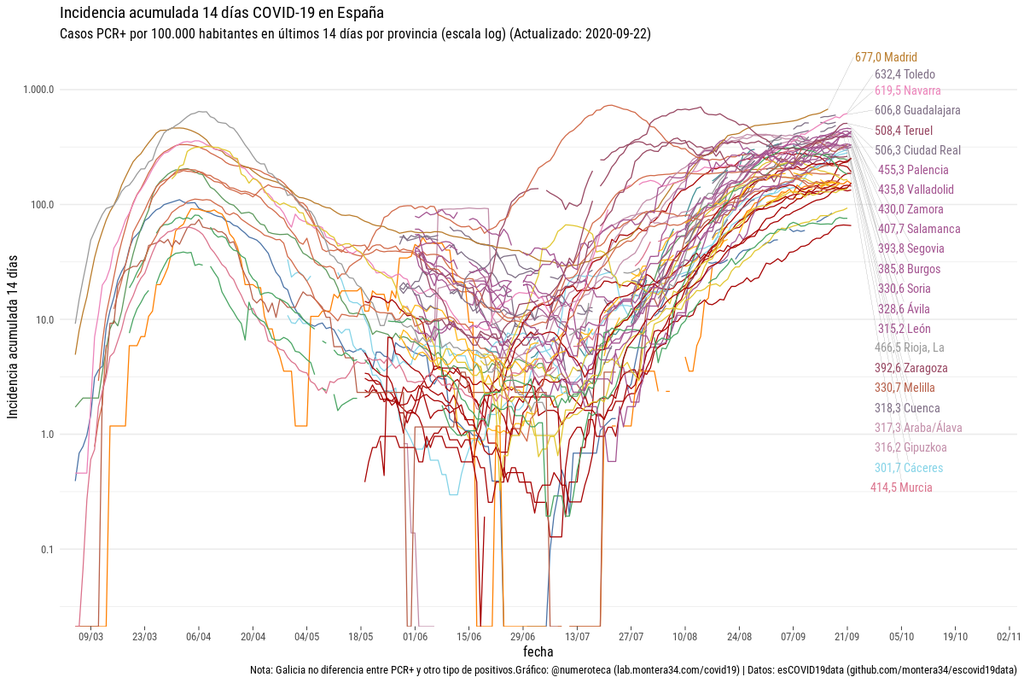

## IA7 por CCAA

Incidencia acumulada 7 días por 100.000 habitantes. Casos PCR+. Datos de Escovid19data recopilados de las CCAA.

| ccaa | 08-24 | 08-25 | 08-26 | 08-27 | 08-28 | 08-29 | 08-30 | 08-31 | 09-01 | 09-02 | 09-03 | 09-04 | 09-05 | 09-06 | 09-07 | 09-08 | 09-09 | 09-10 | 09-11 | 09-12 | 09-13 | 09-14 | 09-15 | 09-16 | 09-17 | 09-18 | 09-19 | 09-20 | 09-21 | … |
| --- | --- | --- | --- | --- | --- | --- | --- | --- | --- | --- | --- | --- | --- | --- | --- | --- | --- | --- | --- | --- | --- | --- | --- | --- | --- | --- | --- | --- | --- | --- |
| Andalucía | 49 | 51 | 54 | 57 | 59 | 62 | 62 | 63 | 67 | 67 | 70 | 71 | 73 | 74 | 75 | 76 | 74 | 74 | 76 | 77 | 78 | 78 | 78 | 79 | 84 | 89 | 93 | 93 | 95 | … |
| Aragón | 202 | 192 | 160 | 148 | 153 | 136 | 132 | 140 | 132 | 128 | 140 | 134 | 144 | 151 | 148 | 153 | 162 | 164 | 182 | 176 | 191 | 192 | 193 | 189 | 193 | 191 | 197 | 184 | 191 | … |
| Asturias | 22 | 23 | 25 | 24 | 25 | 26 | 27 | 25 | 23 | 24 | 25 | 21 | 18 | 35 | 33 | 37 | 34 | 34 | 34 | 34 | 36 | 39 | 40 | 45 | 50 | 50 | 50 | 57 | 58 | … |
| Balears, Illes | 108 | 167 | 177 | 206 | 201 | 201 | 201 | 215 | 151 | 150 | 130 | 134 | 134 | 134 | 116 | 128 | 128 | 135 | 134 | 134 | 134 | 107 | 80 | 52 | 18 |  |  |  |  | … |
| C. Valenciana | 49 | 58 | 69 | 68 | 73 | 75 | 75 | 83 | 85 | 78 | 80 | 80 | 81 | 81 | 75 | 70 | 76 | 78 | 83 | 80 | 80 | 77 | 82 | 78 | 79 | 70 | 73 | 73 | 71 | … |
| C.-La Mancha | 101 | 114 | 118 | 125 | 132 | 132 | 132 | 158 | 162 | 173 | 180 | 193 | 193 | 193 | 214 | 216 | 212 | 220 | 216 | 216 | 216 | 232 | 228 | 237 | 238 | 250 | 250 | 250 | 267 | … |
| Canarias | 60 | 68 | 74 | 81 | 86 | 86 | 91 | 98 | 97 | 95 | 97 | 101 | 105 | 102 | 98 | 96 | 97 | 90 | 84 | 80 | 76 | 76 | 74 | 70 | 67 | 66 | 62 | 60 | 55 | … |
| Cantabria | 74 | 79 | 86 | 89 | 95 | 101 | 107 | 108 | 114 | 116 | 125 | 124 | 125 | 124 | 127 | 126 | 138 | 139 | 139 | 140 | 148 | 148 | 144 | 135 | 118 | 120 | 109 | 102 | 98 | … |
| Castilla y León | 97 | 96 | 103 | 107 | 109 | 115 | 135 | 140 | 135 | 135 | 129 | 130 | 132 | 130 | 134 | 139 | 135 | 145 | 149 | 165 | 172 | 177 | 181 | 196 | 192 | 205 | 210 | 209 | 206 | … |
| Cataluña | 97 | 98 | 102 | 102 | 100 | 101 | 101 | 101 | 101 | 96 | 95 | 97 | 97 | 97 | 95 | 94 | 94 | 97 | 84 | 85 | 85 | 85 | 87 | 89 | 85 | 96 | 95 | 95 | 93 | … |

[output cut: 9 more lines]

Nota: Galicia incluye algunos casos que son por anticuerpos en su serie, pero al no disponer de una serie con solo casos PCR+ se usa la de casos acumulados. Ver wiki https://github.com/montera34/escovid19data/wiki#informaci%C3%B3n-obtenida-a-partir-del-4-de-junio

## IA14 por CCAA

Incidencia acumulada 14 días por 100.000 habitantes. Casos PCR+. Datos de Escovid19data recopilados de las CCAA.

| ccaa | 08-24 | 08-25 | 08-26 | 08-27 | 08-28 | 08-29 | 08-30 | 08-31 | 09-01 | 09-02 | 09-03 | 09-04 | 09-05 | 09-06 | 09-07 | 09-08 | 09-09 | 09-10 | 09-11 | 09-12 | 09-13 | 09-14 | 09-15 | 09-16 | 09-17 | 09-18 | 09-19 | 09-20 | 09-21 | … |
| --- | --- | --- | --- | --- | --- | --- | --- | --- | --- | --- | --- | --- | --- | --- | --- | --- | --- | --- | --- | --- | --- | --- | --- | --- | --- | --- | --- | --- | --- | --- |
| Andalucía | 84 | 88 | 94 | 99 | 105 | 109 | 111 | 111 | 118 | 121 | 127 | 130 | 135 | 136 | 137 | 142 | 141 | 143 | 147 | 150 | 152 | 152 | 153 | 154 | 158 | 165 | 170 | 171 | 173 | … |
| Aragón | 440 | 442 | 432 | 407 | 386 | 370 | 353 | 342 | 324 | 288 | 288 | 286 | 281 | 283 | 287 | 285 | 290 | 304 | 315 | 321 | 342 | 340 | 345 | 352 | 357 | 373 | 374 | 376 | 383 | … |
| Asturias | 37 | 40 | 40 | 41 | 45 | 48 | 44 | 46 | 46 | 49 | 49 | 46 | 44 | 61 | 58 | 60 | 58 | 59 | 55 | 52 | 70 | 72 | 76 | 79 | 84 | 84 | 84 | 93 | 98 | … |
| Balears, Illes | 211 | 270 | 275 | 297 | 302 | 302 | 302 | 323 | 318 | 327 | 336 | 335 | 335 | 335 | 331 | 279 | 278 | 266 | 268 | 268 | 268 | 223 | 208 | 180 | 154 |  |  |  |  | … |
| C. Valenciana | 91 | 102 | 113 | 115 | 119 | 130 | 130 | 133 | 143 | 147 | 148 | 154 | 156 | 156 | 158 | 156 | 154 | 158 | 163 | 161 | 161 | 152 | 152 | 154 | 157 | 153 | 152 | 152 | 148 | … |
| C.-La Mancha | 164 | 176 | 186 | 201 | 216 | 216 | 216 | 259 | 276 | 291 | 305 | 325 | 325 | 325 | 372 | 378 | 385 | 400 | 409 | 409 | 409 | 446 | 444 | 448 | 458 | 466 | 466 | 466 | 499 | … |
| Canarias | 94 | 102 | 112 | 123 | 131 | 138 | 148 | 159 | 165 | 169 | 178 | 188 | 191 | 193 | 197 | 194 | 191 | 187 | 186 | 184 | 178 | 175 | 171 | 167 | 157 | 150 | 142 | 136 | 132 | … |
| Cantabria | 138 | 141 | 149 | 154 | 163 | 172 | 175 | 183 | 193 | 202 | 214 | 219 | 226 | 230 | 235 | 240 | 254 | 264 | 263 | 265 | 272 | 274 | 269 | 273 | 257 | 258 | 249 | 250 | 245 | … |
| Castilla y León | 170 | 169 | 180 | 192 | 199 | 206 | 224 | 237 | 232 | 238 | 236 | 239 | 247 | 265 | 274 | 274 | 270 | 274 | 280 | 297 | 302 | 311 | 320 | 331 | 337 | 354 | 375 | 382 | 383 | … |
| Cataluña | 183 | 186 | 191 | 194 | 195 | 195 | 196 | 197 | 198 | 198 | 196 | 197 | 198 | 197 | 195 | 194 | 190 | 191 | 181 | 182 | 182 | 180 | 181 | 183 | 181 | 180 | 179 | 180 | 178 | … |

[output cut: 9 more lines]

Nota: Galicia incluye algunos casos que son por anticuerpos en su serie, pero al no disponer de una serie con solo casos PCR+ se usa la de casos acumulados. Ver wiki https://github.com/montera34/escovid19data/wiki#informaci%C3%B3n-obtenida-a-partir-del-4-de-junio

# Hospitalizados

## Hospitalizados por provincia

Personas hospitalizadas en planta (prevalentes). Datos de Escovid19data recopilados de las CCAA.

| province | 08-24 | 08-25 | 08-26 | 08-27 | 08-28 | 08-29 | 08-30 | 08-31 | 09-01 | 09-02 | 09-03 | 09-04 | 09-05 | 09-06 | 09-07 | 09-08 | 09-09 | 09-10 | 09-11 | 09-12 | 09-13 | 09-14 | 09-15 | 09-16 | 09-17 | 09-18 | 09-19 | 09-20 | 09-21 | … |
| --- | --- | --- | --- | --- | --- | --- | --- | --- | --- | --- | --- | --- | --- | --- | --- | --- | --- | --- | --- | --- | --- | --- | --- | --- | --- | --- | --- | --- | --- | --- |
| Albacete | 36 | 36 | 42 | 43 | 41 |  |  | 47 | 49 | 53 | 54 | 55 |  |  | 46 | 52 | 60 | 59 | 63 |  |  | 60 | 62 | 61 | 62 | 53 |  |  | 57 | … |
| Alicante/Alacant | 86 | 78 | 75 | 67 | 71 |  |  | 86 | 96 | 90 | 85 | 107 |  |  | 107 | 113 | 133 | 122 | 116 |  |  | 121 | 121 | 123 | 114 | 121 |  |  | 142 | … |
| Almería | 80 | 85 | 89 | 92 | 97 | 93 | 100 | 110 | 114 | 107 | 102 | 98 | 84 | 84 | 92 | 88 | 79 | 69 | 66 | 66 | 73 |  |  | 66 | 57 | 50 | 46 | 45 |  | … |
| Araba/Álava | 109 | 108 | 108 | 112 | 111 | 112 | 115 | 119 | 126 | 128 | 134 | 120 | 125 | 129 | 119 | 112 | 115 | 101 | 96 | 102 | 107 | 109 | 111 | 109 | 103 | 102 | 101 | 104 | 106 | … |
| Asturias | 9 | 10 | 9 | 13 |  |  | 13 | 23 | 22 | 27 | 28 |  |  | 36 | 33 | 35 | 35 | 38 |  |  | 37 | 36 | 33 | 33 | 29 |  |  | 33 | 38 | … |
| Ávila | 24 | 28 | 30 | 29 | 28 | 31 | 37 | 36 | 27 | 26 | 25 | 25 | 26 | 27 | 31 | 33 | 35 | 33 | 33 | 28 | 26 | 29 | 34 | 29 | 32 | 30 | 34 | 36 | 40 | … |
| Badajoz | 21 | 24 | 24 | 25 | 23 | 22 | 28 | 29 | 26 | 26 | 27 | 26 | 30 | 36 | 38 | 40 | 37 | 44 | 49 | 56 | 62 | 64 | 62 | 64 | 69 | 78 | 83 | 96 | 100 | … |
| Balears, Illes | 219 | 242 | 229 | 241 | 254 |  |  | 284 | 290 | 246 | 299 | 298 |  |  | 347 | 351 | 347 | 339 | 323 | 320 | 326 | 327 | 318 | 311 | 299 | 307 | 305 | 316 | 328 | … |
| Barcelona | 523 | 508 | 497 | 488 | 463 | 495 | 516 | 524 | 520 | 489 | 477 | 471 | 496 | 516 | 514 | 523 | 511 | 500 | 509 | 528 | 561 | 552 | 555 | 548 | 561 | 538 | 549 | 579 | 590 | … |
| Bizkaia | 255 | 251 | 248 | 256 | 273 | 279 | 290 | 276 | 287 | 277 | 262 | 251 | 267 | 281 | 258 | 266 | 277 | 274 | 262 | 278 | 292 | 289 | 287 | 279 | 262 | 263 | 269 | 280 | 262 | … |

[output cut: 42 more lines]

# UCI

## Por provincia

Personas hospitalizadas en unidad de cuidad intensivos (prevalentes). Datos de Escovid19data recopilados de las CCAA.

| province | 08-24 | 08-25 | 08-26 | 08-27 | 08-28 | 08-29 | 08-30 | 08-31 | 09-01 | 09-02 | 09-03 | 09-04 | 09-05 | 09-06 | 09-07 | 09-08 | 09-09 | 09-10 | 09-11 | 09-12 | 09-13 | 09-14 | 09-15 | 09-16 | 09-17 | 09-18 | 09-19 | 09-20 | 09-21 | … |
| --- | --- | --- | --- | --- | --- | --- | --- | --- | --- | --- | --- | --- | --- | --- | --- | --- | --- | --- | --- | --- | --- | --- | --- | --- | --- | --- | --- | --- | --- | --- |
| Albacete | 2 | 2 | 3 | 3 | 3 |  |  | 3 | 4 | 3 | 2 | 4 |  |  | 6 | 5 | 5 | 5 | 6 |  |  | 5 | 5 | 5 | 6 | 7 |  |  | 6 | … |
| Alicante/Alacant | 10 | 13 | 14 | 15 | 11 |  |  | 14 | 15 | 19 | 20 | 25 |  |  | 31 | 30 | 26 | 30 | 32 |  |  | 33 | 29 | 29 | 27 | 29 |  |  | 34 | … |
| Almería | 14 | 13 | 14 | 16 | 18 | 19 | 20 | 21 | 21 | 19 | 18 | 18 | 17 | 18 | 16 | 16 | 17 | 13 | 12 | 13 | 14 |  |  | 16 | 13 | 15 | 14 | 13 |  | … |
| Araba/Álava | 13 | 11 | 9 | 10 | 12 | 11 | 10 | 13 | 13 | 14 | 14 | 13 | 12 | 12 | 13 | 13 | 12 | 14 | 14 | 13 | 13 | 14 | 13 | 13 | 11 | 11 | 13 | 15 | 13 | … |
| Asturias | 2 | 2 | 2 | 2 |  |  | 4 | 4 | 5 | 4 | 5 |  |  | 7 | 7 | 8 | 9 | 8 |  |  | 10 | 11 | 11 | 10 | 12 |  |  | 11 | 11 | … |
| Ávila | 0 | 1 | 2 | 2 | 3 | 3 | 3 | 3 | 3 | 2 | 3 | 3 | 2 | 2 | 2 | 2 | 2 | 2 | 2 | 2 | 2 | 2 | 2 | 2 | 2 | 3 | 3 | 5 | 5 | … |
| Badajoz | 1 | 2 | 2 | 2 | 2 | 3 | 3 | 3 | 4 | 3 | 5 | 5 | 5 | 5 | 5 | 5 | 6 | 6 | 7 | 8 | 8 | 8 | 7 | 7 | 7 | 7 | 7 | 10 | 11 | … |
| Balears, Illes | 33 | 37 | 33 | 41 | 43 |  |  | 54 | 51 | 51 | 58 | 58 |  |  | 61 | 59 | 57 | 58 | 62 | 62 | 66 | 55 | 69 | 64 | 63 | 63 | 65 | 66 | 64 | … |
| Barcelona | 95 | 92 | 86 | 86 | 83 | 91 | 96 | 91 | 90 | 92 | 91 | 88 | 86 | 90 | 89 | 86 | 84 | 85 | 87 | 91 | 91 | 83 | 85 | 88 | 92 | 88 | 88 | 95 | 93 | … |
| Bizkaia | 16 | 17 | 18 | 19 | 21 | 23 | 23 | 20 | 24 | 27 | 29 | 25 | 24 | 24 | 28 | 30 | 28 | 32 | 32 | 31 | 31 | 26 | 23 | 24 | 25 | 27 | 26 | 26 | 28 | … |

[output cut: 42 more lines]

# Fallecidos

Para Euskadi se incluyen solamente los fallecidos en hospitales.

## Por comunidades autónomas

Personas fallecidas diarias. Datos de Escovid19data recopilados de las CCAA. Datos de Escovid19data recopilados de las CCAA.

| ccaa | 08-24 | 08-25 | 08-26 | 08-27 | 08-28 | 08-29 | 08-30 | 08-31 | 09-01 | 09-02 | 09-03 | 09-04 | 09-05 | 09-06 | 09-07 | 09-08 | 09-09 | 09-10 | 09-11 | 09-12 | 09-13 | 09-14 | 09-15 | 09-16 | 09-17 | 09-18 | 09-19 | 09-20 | 09-21 | … |
| --- | --- | --- | --- | --- | --- | --- | --- | --- | --- | --- | --- | --- | --- | --- | --- | --- | --- | --- | --- | --- | --- | --- | --- | --- | --- | --- | --- | --- | --- | --- |
| Andalucía | 2 | 5 | 4 | 1 | 4 | 5 | 3 | 5 | 7 | 6 | 3 | 7 | 7 | 6 | 9 | 8 | 5 | 16 | 7 | 14 | 0 | 6 | 22 | 16 | 25 | 6 | 11 | 3 | 14 | … |
| Aragón | 11 | 6 | 5 | 0 | 0 | 0 | 17 | 5 | 14 | 5 | 10 | 0 | 0 | 8 | 8 | 12 | 7 | 12 | 0 | 0 | 19 | 9 | 8 | 7 | 7 | 0 | 0 | 19 | 0 | … |
| Asturias | 0 | 0 | 0 | 0 | 0 | 0 | 0 | 0 | 0 | 0 | 0 | 2 | 0 | 0 | 1 | 0 | 0 | 0 | 0 | 0 | 1 | 1 | 0 | 1 | 0 | 0 | 0 | 0 | 1 | … |
| Balears, Illes | 0 | 1 | 2 | 0 | 1 | 0 | 0 | 1 | 5 | 0 | 4 | 1 | 0 | 0 | 2 | 4 | 1 | 4 | 5 | 0 | 0 | 1 | 5 | 4 | 1 | 1 | 0 | 0 | 7 | … |
| C. Valenciana | 3 | 4 | 1 | 3 | 3 | 0 | 0 | 1 | 7 | 1 | 3 | 8 | 0 | 0 | 7 | 2 | 5 | 4 | 9 | 0 | 0 | 5 | 3 | 9 | 9 | 2 | 0 | 0 | 0 | … |
| C.-La Mancha | 5 | 2 | 2 | 0 | 1 | 0 | 0 | 2 | 0 | 1 | 9 | 1 | 0 | 0 | 8 | 8 | 2 | 2 | 4 | 0 | 0 | 20 | 9 | 10 | 5 | 8 | 0 | 0 | 21 | … |
| Canarias | 1 | 0 | 1 | 2 | 1 | 1 | 1 | 0 | 0 | 1 | 3 | 1 | 0 | 4 | 3 | 1 | 2 | 0 | 0 | 4 | 0 | 5 | 4 | 4 | 3 | 1 | 2 | 2 | 1 | … |
| Cantabria | 0 | 0 | 0 | 0 | 0 | 2 | 0 | 1 | 0 | 1 | 0 | 1 | 0 | 0 | 1 | 0 | 1 | 0 | 0 | 0 | 0 | 0 | 1 | 0 | 3 | 1 | 1 | 0 | 0 | … |
| Castilla y León | 3 | 2 | 3 | 3 | 4 | 11 | 3 | 4 | 9 | 0 | 4 | 2 | 5 | 5 | 5 | 3 | 3 | 6 | 2 | 4 | 8 | 7 | 4 | 8 | 5 | 8 | 7 | 6 | 9 | … |
| Cataluña | 15 | 7 | 10 | 11 | 11 | 6 | 11 | 7 | 13 | 9 | 13 | 12 | 10 | 10 | 9 | 9 | 12 | 13 | 7 | 5 | 8 | 17 | 10 | 14 | 12 | 8 | 10 | 5 | 0 | … |
| Ceuta | 0 | 0 | 0 | 0 | 1 | 0 | 0 | 0 | 0 | 0 | 0 | 0 | 0 | 0 | 1 | 0 | 1 | 0 | 1 | 0 | 1 | 0 | 0 | 0 | 0 | 0 | 0 | 1 | 0 | … |
| Extremadura | 0 | 0 | 0 | 0 | 0 | 1 | 0 | 1 | 1 | 1 | 0 | 2 | 0 | 1 | 4 | 1 | 0 | 0 | 0 | 0 | 0 | 1 | 1 | 2 | 4 | 2 | 2 | 4 | 2 | … |
| Galicia | 0 | 0 | 1 | 1 | 1 | 3 | 2 | 3 | 0 | 6 | 2 | 4 | 3 | 2 | 1 | 1 | 8 | 4 | 2 | 3 | 6 | 6 | 4 | 1 | 6 | 5 | 4 | 5 | 4 | … |
| Madrid | 13 | 10 | 15 | 17 | 0 | 0 | 45 | 18 | 21 | 23 | 20 | 0 | 0 | 53 | 21 | 27 | 23 | 26 | 0 | 0 | 90 | 25 | 27 | 30 | 33 | 0 | 0 | 117 | 39 | … |
| Melilla | 0 | 0 | 0 | 0 | 0 | 0 | 0 | 0 | 0 | 0 | 1 | 0 | 0 | 0 | 0 | 0 | 0 | 0 | 0 | 1 | 0 | 0 | 0 | 0 | 0 | 0 | 0 | 0 | 0 | … |
| Murcia | 1 | 1 | 0 | 0 | 1 | 0 | 0 | 0 | 1 | 0 | 1 | 2 | 0 | 1 | 0 | 2 | 2 | 4 | 1 | 2 | 3 | 1 | 3 | 5 | 2 | 2 | 1 | 1 | 1 | … |
| Navarra | 0 | 0 | 0 | 0 | 0 | 1 | 0 | 1 | 1 | 0 | 0 | 3 | 0 | 1 | 0 | 0 | 1 | 1 | 0 | 3 | 2 | 1 | 1 | 1 | 3 | 2 | 2 | 0 | 5 | … |
| País Vasco | 5 | 4 | 5 | 4 | 5 | 7 | 3 | 2 | 6 | 6 | 9 | 8 | 7 | 3 | 6 | 8 | 3 | 3 | 4 | 9 | 4 | 7 | 7 | 16 | 15 | 5 | 10 | 5 | 8 | … |
| Rioja, La | 1 | 1 | 0 | 0 | 0 | 0 | 0 | 1 | 2 | 1 | 0 | 1 | 0 | 0 | 3 | 2 | 1 | 1 | 1 | 0 | 0 | 2 | 3 | 0 | 4 | 2 | 0 | 0 | 6 | … |
| España | 60 | 43 | 49 | 42 | 33 | 37 | 85 | 52 | 87 | 61 | 82 | 55 | 32 | 94 | 89 | 88 | 77 | 96 | 43 | 45 | 142 | 114 | 112 | 128 | 137 | 53 | 50 | 168 | 118 | … |

## Por comunidades autónomas (media diaria)

Media de personas fallecidas diarias (ventana de 7 días). Datos de Escovid19data recopilados de las CCAA.

| ccaa | 08-24 | 08-25 | 08-26 | 08-27 | 08-28 | 08-29 | 08-30 | 08-31 | 09-01 | 09-02 | 09-03 | 09-04 | 09-05 | 09-06 | 09-07 | 09-08 | 09-09 | 09-10 | 09-11 | 09-12 | 09-13 | 09-14 | 09-15 | 09-16 | 09-17 | 09-18 | 09-19 | 09-20 | 09-21 | … |
| --- | --- | --- | --- | --- | --- | --- | --- | --- | --- | --- | --- | --- | --- | --- | --- | --- | --- | --- | --- | --- | --- | --- | --- | --- | --- | --- | --- | --- | --- | --- |
| Andalucía | 2.1 | 2.4 | 2.9 | 3.0 | 2.9 | 3.3 | 3.4 | 3.9 | 4.1 | 4.4 | 4.7 | 5.1 | 5.4 | 5.9 | 6.4 | 6.6 | 6.4 | 8.3 | 8.3 | 9.3 | 8.4 | 8.0 | 10.0 | 11.6 | 12.9 | 12.7 | 12.3 | 12.7 | 13.9 | … |
| Aragón | 11.3 | 10.0 | 8.9 | 8.9 | 8.9 | 8.9 | 5.6 | 4.7 | 5.9 | 5.9 | 7.3 | 7.3 | 7.3 | 6.0 | 6.4 | 6.1 | 6.4 | 6.7 | 6.7 | 6.7 | 8.3 | 8.4 | 7.9 | 7.9 | 7.1 | 7.1 | 7.1 | 7.1 | 5.9 | … |
| Asturias | 0.1 | 0.1 | 0.1 | 0.1 | 0.1 | 0.0 | 0.0 | 0.0 | 0.0 | 0.0 | 0.0 | 0.3 | 0.3 | 0.3 | 0.4 | 0.4 | 0.4 | 0.4 | 0.1 | 0.1 | 0.3 | 0.3 | 0.3 | 0.4 | 0.4 | 0.4 | 0.4 | 0.3 | 0.3 | … |
| Balears, Illes | 0.4 | 0.3 | 0.6 | 0.6 | 0.6 | 0.6 | 0.6 | 0.7 | 1.3 | 1.0 | 1.6 | 1.6 | 1.6 | 1.6 | 1.7 | 1.6 | 1.7 | 1.7 | 2.3 | 2.3 | 2.3 | 2.1 | 2.3 | 2.7 | 2.3 | 1.7 | 1.7 | 1.7 | 2.6 | … |
| C. Valenciana | 1.7 | 2.0 | 1.9 | 1.9 | 2.0 | 2.0 | 2.0 | 1.7 | 2.1 | 2.1 | 2.1 | 2.9 | 2.9 | 2.9 | 3.7 | 3.0 | 3.6 | 3.7 | 3.9 | 3.9 | 3.9 | 3.6 | 3.7 | 4.3 | 5.0 | 4.0 | 4.0 | 4.0 | 3.3 | … |
| C.-La Mancha | 1.0 | 1.3 | 1.3 | 1.3 | 1.4 | 1.4 | 1.4 | 1.0 | 0.7 | 0.6 | 1.9 | 1.9 | 1.9 | 1.9 | 2.7 | 3.9 | 4.0 | 3.0 | 3.4 | 3.4 | 3.4 | 5.1 | 5.3 | 6.4 | 6.9 | 7.4 | 7.4 | 7.4 | 7.6 | … |
| Canarias | 0.3 | 0.3 | 0.4 | 0.7 | 0.7 | 0.9 | 1.0 | 0.9 | 0.9 | 0.9 | 1.0 | 1.0 | 0.9 | 1.3 | 1.7 | 1.9 | 2.0 | 1.6 | 1.4 | 2.0 | 1.4 | 1.7 | 2.1 | 2.4 | 2.9 | 3.0 | 2.7 | 3.0 | 2.4 | … |
| Cantabria | 0.1 | 0.1 | 0.0 | 0.0 | 0.0 | 0.3 | 0.3 | 0.4 | 0.4 | 0.6 | 0.6 | 0.7 | 0.4 | 0.4 | 0.4 | 0.4 | 0.4 | 0.4 | 0.3 | 0.3 | 0.3 | 0.1 | 0.3 | 0.1 | 0.6 | 0.7 | 0.9 | 0.9 | 0.9 | … |
| Castilla y León | 1.3 | 1.6 | 2.0 | 2.1 | 2.7 | 4.3 | 4.1 | 4.3 | 5.3 | 4.9 | 5.0 | 4.7 | 3.9 | 4.1 | 4.3 | 3.4 | 3.9 | 4.1 | 4.1 | 4.0 | 4.4 | 4.7 | 4.9 | 5.6 | 5.4 | 6.3 | 6.7 | 6.4 | 6.7 | … |
| Cataluña | 10.4 | 10.0 | 9.7 | 9.7 | 10.7 | 10.3 | 10.1 | 9.0 | 9.9 | 9.7 | 10.0 | 10.1 | 10.7 | 10.6 | 10.9 | 10.3 | 10.7 | 10.7 | 10.0 | 9.3 | 9.0 | 10.1 | 10.3 | 10.6 | 10.4 | 10.6 | 11.3 | 10.9 | 8.4 | … |
| Ceuta | 0.0 | 0.0 | 0.0 | 0.0 | 0.1 | 0.1 | 0.1 | 0.1 | 0.1 | 0.1 | 0.1 | 0.0 | 0.0 | 0.0 | 0.1 | 0.1 | 0.3 | 0.3 | 0.4 | 0.4 | 0.6 | 0.4 | 0.4 | 0.3 | 0.3 | 0.1 | 0.1 | 0.1 | 0.1 | … |
| Extremadura | 0.4 | 0.4 | 0.3 | 0.1 | 0.0 | 0.1 | 0.1 | 0.3 | 0.4 | 0.6 | 0.6 | 0.9 | 0.7 | 0.9 | 1.3 | 1.3 | 1.1 | 1.1 | 0.9 | 0.9 | 0.7 | 0.3 | 0.3 | 0.6 | 1.1 | 1.4 | 1.7 | 2.3 | 2.4 | … |
| Galicia | 1.1 | 1.1 | 1.3 | 1.3 | 1.1 | 1.0 | 1.1 | 1.6 | 1.6 | 2.3 | 2.4 | 2.9 | 2.9 | 2.9 | 2.6 | 2.7 | 3.0 | 3.3 | 3.0 | 3.0 | 3.6 | 4.3 | 4.7 | 3.7 | 4.0 | 4.4 | 4.6 | 4.4 | 4.1 | … |
| Madrid | 9.9 | 10.1 | 11.3 | 12.0 | 12.0 | 12.0 | 14.3 | 15.0 | 16.6 | 17.7 | 18.1 | 18.1 | 18.1 | 19.3 | 19.7 | 20.6 | 20.6 | 21.4 | 21.4 | 21.4 | 26.7 | 27.3 | 27.3 | 28.3 | 29.3 | 29.3 | 29.3 | 33.1 | 35.1 | … |
| Melilla | 0.0 | 0.0 | 0.0 | 0.0 | 0.0 | 0.0 | 0.0 | 0.0 | 0.0 | 0.0 | 0.1 | 0.1 | 0.1 | 0.1 | 0.1 | 0.1 | 0.1 | 0.0 | 0.0 | 0.1 | 0.1 | 0.1 | 0.1 | 0.1 | 0.1 | 0.1 | 0.0 | 0.0 | 0.0 | … |
| Murcia | 0.4 | 0.4 | 0.4 | 0.4 | 0.4 | 0.4 | 0.4 | 0.3 | 0.3 | 0.3 | 0.4 | 0.6 | 0.6 | 0.7 | 0.7 | 0.9 | 1.1 | 1.6 | 1.4 | 1.7 | 2.0 | 2.1 | 2.3 | 2.7 | 2.4 | 2.6 | 2.4 | 2.1 | 2.1 | … |
| Navarra | 0.1 | 0.1 | 0.1 | 0.1 | 0.1 | 0.1 | 0.1 | 0.3 | 0.4 | 0.4 | 0.4 | 0.9 | 0.7 | 0.9 | 0.7 | 0.6 | 0.7 | 0.9 | 0.4 | 0.9 | 1.0 | 1.1 | 1.3 | 1.3 | 1.6 | 1.9 | 1.7 | 1.4 | 2.0 | … |
| País Vasco | 3.4 | 3.9 | 4.3 | 4.7 | 4.6 | 5.1 | 4.7 | 4.3 | 4.6 | 4.7 | 5.4 | 5.9 | 5.9 | 5.9 | 6.4 | 6.7 | 6.3 | 5.4 | 4.9 | 5.1 | 5.3 | 5.4 | 5.3 | 7.1 | 8.9 | 9.0 | 9.1 | 9.3 | 9.4 | … |
| Rioja, La | 0.3 | 0.3 | 0.3 | 0.3 | 0.3 | 0.3 | 0.3 | 0.3 | 0.4 | 0.6 | 0.6 | 0.7 | 0.7 | 0.7 | 1.0 | 1.0 | 1.0 | 1.1 | 1.1 | 1.1 | 1.1 | 1.0 | 1.1 | 1.0 | 1.4 | 1.6 | 1.6 | 1.6 | 2.1 | … |
| España | 44.3 | 44.4 | 45.8 | 47.2 | 48.6 | 51.1 | 49.6 | 48.8 | 55.0 | 56.8 | 62.3 | 65.7 | 65.0 | 66.4 | 71.2 | 71.6 | 73.7 | 75.7 | 74.0 | 75.9 | 82.8 | 86.1 | 89.9 | 97.1 | 103.0 | 104.3 | 105.0 | 108.7 | 109.3 | … |

Últimas fechas con datos no consolidados.

## Por comunidades autónomas (media diaria) por 100.000 habitantes

Media de personas fallecidas diarias (ventana de 7 días). Datos de Escovid19data recopilados de las CCAA.

| ccaa | 08-24 | 08-25 | 08-26 | 08-27 | 08-28 | 08-29 | 08-30 | 08-31 | 09-01 | 09-02 | 09-03 | 09-04 | 09-05 | 09-06 | 09-07 | 09-08 | 09-09 | 09-10 | 09-11 | 09-12 | 09-13 | 09-14 | 09-15 | 09-16 | 09-17 | 09-18 | 09-19 | 09-20 | 09-21 | … |
| --- | --- | --- | --- | --- | --- | --- | --- | --- | --- | --- | --- | --- | --- | --- | --- | --- | --- | --- | --- | --- | --- | --- | --- | --- | --- | --- | --- | --- | --- | --- |
| Andalucía | 0.02 | 0.03 | 0.03 | 0.04 | 0.03 | 0.04 | 0.04 | 0.05 | 0.05 | 0.05 | 0.06 | 0.06 | 0.06 | 0.07 | 0.08 | 0.08 | 0.08 | 0.10 | 0.10 | 0.11 | 0.10 | 0.10 | 0.12 | 0.14 | 0.15 | 0.15 | 0.15 | 0.15 | 0.17 | … |
| Aragón | 0.86 | 0.76 | 0.67 | 0.67 | 0.67 | 0.67 | 0.42 | 0.36 | 0.45 | 0.45 | 0.55 | 0.55 | 0.55 | 0.45 | 0.49 | 0.46 | 0.49 | 0.51 | 0.51 | 0.51 | 0.63 | 0.64 | 0.60 | 0.60 | 0.54 | 0.54 | 0.54 | 0.54 | 0.45 | … |
| Asturias | 0.01 | 0.01 | 0.01 | 0.01 | 0.01 | 0.00 | 0.00 | 0.00 | 0.00 | 0.00 | 0.00 | 0.03 | 0.03 | 0.03 | 0.04 | 0.04 | 0.04 | 0.04 | 0.01 | 0.01 | 0.03 | 0.03 | 0.03 | 0.04 | 0.04 | 0.04 | 0.04 | 0.03 | 0.03 | … |
| Balears, Illes | 0.03 | 0.03 | 0.05 | 0.05 | 0.05 | 0.05 | 0.05 | 0.06 | 0.11 | 0.09 | 0.14 | 0.14 | 0.14 | 0.14 | 0.15 | 0.14 | 0.15 | 0.15 | 0.20 | 0.20 | 0.20 | 0.18 | 0.20 | 0.23 | 0.20 | 0.15 | 0.15 | 0.15 | 0.23 | … |
| C. Valenciana | 0.03 | 0.04 | 0.04 | 0.04 | 0.04 | 0.04 | 0.04 | 0.03 | 0.04 | 0.04 | 0.04 | 0.06 | 0.06 | 0.06 | 0.07 | 0.06 | 0.07 | 0.07 | 0.08 | 0.08 | 0.08 | 0.07 | 0.07 | 0.09 | 0.10 | 0.08 | 0.08 | 0.08 | 0.07 | … |
| C.-La Mancha | 0.05 | 0.06 | 0.06 | 0.06 | 0.07 | 0.07 | 0.07 | 0.05 | 0.03 | 0.03 | 0.09 | 0.09 | 0.09 | 0.09 | 0.13 | 0.19 | 0.20 | 0.15 | 0.17 | 0.17 | 0.17 | 0.25 | 0.26 | 0.31 | 0.34 | 0.36 | 0.36 | 0.36 | 0.37 | … |
| Canarias | 0.01 | 0.01 | 0.02 | 0.03 | 0.03 | 0.04 | 0.05 | 0.04 | 0.04 | 0.04 | 0.05 | 0.05 | 0.04 | 0.06 | 0.08 | 0.09 | 0.09 | 0.07 | 0.07 | 0.09 | 0.07 | 0.08 | 0.10 | 0.11 | 0.13 | 0.14 | 0.13 | 0.14 | 0.11 | … |
| Cantabria | 0.02 | 0.02 | 0.00 | 0.00 | 0.00 | 0.05 | 0.05 | 0.07 | 0.07 | 0.10 | 0.10 | 0.12 | 0.07 | 0.07 | 0.07 | 0.07 | 0.07 | 0.07 | 0.05 | 0.05 | 0.05 | 0.02 | 0.05 | 0.02 | 0.10 | 0.12 | 0.15 | 0.15 | 0.15 | … |
| Castilla y León | 0.05 | 0.07 | 0.08 | 0.09 | 0.11 | 0.18 | 0.17 | 0.18 | 0.22 | 0.20 | 0.21 | 0.20 | 0.16 | 0.17 | 0.18 | 0.14 | 0.16 | 0.17 | 0.17 | 0.17 | 0.18 | 0.20 | 0.20 | 0.23 | 0.23 | 0.26 | 0.28 | 0.27 | 0.28 | … |
| Cataluña | 0.14 | 0.13 | 0.13 | 0.13 | 0.14 | 0.13 | 0.13 | 0.12 | 0.13 | 0.13 | 0.13 | 0.13 | 0.14 | 0.14 | 0.14 | 0.13 | 0.14 | 0.14 | 0.13 | 0.12 | 0.12 | 0.13 | 0.13 | 0.14 | 0.14 | 0.14 | 0.15 | 0.14 | 0.11 | … |
| Ceuta | 0.00 | 0.00 | 0.00 | 0.00 | 0.12 | 0.12 | 0.12 | 0.12 | 0.12 | 0.12 | 0.12 | 0.00 | 0.00 | 0.00 | 0.12 | 0.12 | 0.35 | 0.35 | 0.47 | 0.47 | 0.71 | 0.47 | 0.47 | 0.35 | 0.35 | 0.12 | 0.12 | 0.12 | 0.12 | … |
| Extremadura | 0.04 | 0.04 | 0.03 | 0.01 | 0.00 | 0.01 | 0.01 | 0.03 | 0.04 | 0.06 | 0.06 | 0.08 | 0.07 | 0.08 | 0.12 | 0.12 | 0.10 | 0.10 | 0.08 | 0.08 | 0.07 | 0.03 | 0.03 | 0.06 | 0.10 | 0.13 | 0.16 | 0.22 | 0.22 | … |
| Galicia | 0.04 | 0.04 | 0.05 | 0.05 | 0.04 | 0.04 | 0.04 | 0.06 | 0.06 | 0.09 | 0.09 | 0.11 | 0.11 | 0.11 | 0.10 | 0.10 | 0.11 | 0.12 | 0.11 | 0.11 | 0.13 | 0.16 | 0.17 | 0.14 | 0.15 | 0.16 | 0.17 | 0.16 | 0.15 | … |
| Madrid | 0.15 | 0.15 | 0.17 | 0.18 | 0.18 | 0.18 | 0.21 | 0.23 | 0.25 | 0.27 | 0.27 | 0.27 | 0.27 | 0.29 | 0.30 | 0.31 | 0.31 | 0.32 | 0.32 | 0.32 | 0.40 | 0.41 | 0.41 | 0.42 | 0.44 | 0.44 | 0.44 | 0.50 | 0.53 | … |
| Melilla | 0.00 | 0.00 | 0.00 | 0.00 | 0.00 | 0.00 | 0.00 | 0.00 | 0.00 | 0.00 | 0.12 | 0.12 | 0.12 | 0.12 | 0.12 | 0.12 | 0.12 | 0.00 | 0.00 | 0.12 | 0.12 | 0.12 | 0.12 | 0.12 | 0.12 | 0.12 | 0.00 | 0.00 | 0.00 | … |
| Murcia | 0.03 | 0.03 | 0.03 | 0.03 | 0.03 | 0.03 | 0.03 | 0.02 | 0.02 | 0.02 | 0.03 | 0.04 | 0.04 | 0.05 | 0.05 | 0.06 | 0.07 | 0.11 | 0.09 | 0.11 | 0.13 | 0.14 | 0.15 | 0.18 | 0.16 | 0.17 | 0.16 | 0.14 | 0.14 | … |
| Navarra | 0.02 | 0.02 | 0.02 | 0.02 | 0.02 | 0.02 | 0.02 | 0.05 | 0.06 | 0.06 | 0.06 | 0.14 | 0.11 | 0.14 | 0.11 | 0.09 | 0.11 | 0.14 | 0.06 | 0.14 | 0.15 | 0.17 | 0.20 | 0.20 | 0.24 | 0.29 | 0.26 | 0.21 | 0.31 | … |
| País Vasco | 0.15 | 0.18 | 0.19 | 0.21 | 0.21 | 0.23 | 0.21 | 0.19 | 0.21 | 0.21 | 0.24 | 0.27 | 0.27 | 0.27 | 0.29 | 0.30 | 0.29 | 0.24 | 0.22 | 0.23 | 0.24 | 0.24 | 0.24 | 0.32 | 0.40 | 0.41 | 0.41 | 0.42 | 0.43 | … |
| Rioja, La | 0.09 | 0.09 | 0.09 | 0.09 | 0.09 | 0.09 | 0.09 | 0.09 | 0.13 | 0.19 | 0.19 | 0.22 | 0.22 | 0.22 | 0.32 | 0.32 | 0.32 | 0.35 | 0.35 | 0.35 | 0.35 | 0.32 | 0.35 | 0.32 | 0.44 | 0.51 | 0.51 | 0.51 | 0.66 | … |

Últimas fechas con datos no consolidados.

## Por provincia

Personas fallecidas diarias. Datos de Escovid19data recopilados de las CCAA.

| province | 08-24 | 08-25 | 08-26 | 08-27 | 08-28 | 08-29 | 08-30 | 08-31 | 09-01 | 09-02 | 09-03 | 09-04 | 09-05 | 09-06 | 09-07 | 09-08 | 09-09 | 09-10 | 09-11 | 09-12 | 09-13 | 09-14 | 09-15 | 09-16 | 09-17 | 09-18 | 09-19 | 09-20 | 09-21 | … |
| --- | --- | --- | --- | --- | --- | --- | --- | --- | --- | --- | --- | --- | --- | --- | --- | --- | --- | --- | --- | --- | --- | --- | --- | --- | --- | --- | --- | --- | --- | --- |
| Albacete | 0 | 0 | 0 | 0 | 0 |  |  | 0 | 0 | 0 | 3 | 0 |  |  | 5 | 2 | 0 | 0 | 0 |  |  | 1 | 2 | 1 | 1 | 0 |  |  | 1 | … |
| Alicante/Alacant | 0 | 0 | 0 | 0 | 0 | 0 |  | 0 | 4 | 1 | 2 | 2 |  |  | 0 | 0 | 3 | 1 | 2 |  |  | 4 | 1 | 2 | 3 | 1 |  |  |  | … |
| Almería | 1 | 2 | 1 | 0 | 2 | 0 | 2 | 1 | 4 | 3 | 1 | 2 | 1 | 2 | 1 | 1 | 3 | 3 | 1 | 1 | 0 | 1 | 1 | 1 | 4 | 3 | 2 | 1 | 1 | … |
| Araba/Álava | 1 | 1 | 1 | 2 | 1 | 3 | 2 | 0 | 2 | 1 | 1 | 1 | 0 | 0 | 3 | 3 | 0 | 0 | 1 | 1 | 1 | 0 | 0 | 2 | 2 | 0 | 1 | 0 | 3 | … |
| Asturias | 0 | 0 | 0 | 0 |  |  | 0 | 0 | 0 | 0 | 0 | 2 |  | 0 | 1 | 0 | 0 | 0 |  |  | 1 | 1 | 0 | 1 | 0 |  |  | 0 | 1 | … |
| Ávila | 0 | 1 | 1 | 1 | 0 | 3 | 2 | 2 | 2 | 0 | 0 | 1 | 1 | 1 | 1 | 0 | 0 | 1 | 0 | 0 | 1 | 0 | 1 | 1 | 0 | 3 | 0 | 0 | 1 | … |
| Badajoz | 0 | 0 | 0 | 0 | 0 | 1 | 0 | 1 | 0 | 1 | 0 | 1 | 0 | 0 | 4 | 1 | 0 | 0 | 0 | 0 | 0 | 1 | 1 | 2 | 1 | 0 | 1 | 2 | 2 | … |
| Balears, Illes | 0 | 1 | 2 | 0 | 1 |  |  | 1 | 5 | 0 | 4 | 1 |  |  | 2 | 4 | 1 | 4 | 5 | 0 | 0 | 1 | 5 | 4 | 1 | 1 | 0 | 0 | 7 | … |
| Barcelona | 11 | 6 | 9 | 9 | 9 | 6 | 11 | 5 | 11 | 8 | 11 | 11 | 7 | 10 | 7 | 5 | 7 | 10 | 5 | 5 | 6 | 14 | 7 | 10 | 12 | 6 | 8 | 4 | 0 | … |
| Bizkaia | 3 | 2 | 3 | 2 | 3 | 4 | 1 | 2 | 3 | 3 | 6 | 6 | 6 | 3 | 3 | 5 | 2 | 1 | 2 | 4 | 3 | 4 | 5 | 8 | 11 | 2 | 8 | 2 | 4 | … |
| Burgos | 0 | 0 | 0 | 1 | 0 | 2 | 0 | 0 | 1 | 0 | 1 | 0 | 1 | 2 | 0 | 0 | 0 | 2 | 1 | 0 | 1 | 1 | 1 | 2 | 2 | 2 | 3 | 2 | 1 | … |
| Cáceres | 0 | 0 | 0 | 0 | 0 | 0 | 0 | 0 | 1 | 0 | 0 | 1 | 0 | 1 | 0 | 0 | 0 | 0 | 0 | 0 | 0 | 0 | 0 | 0 | 3 | 2 | 1 | 2 | 0 | … |
| Cádiz | 1 | 0 | 0 | 0 | 0 | 2 | 0 | 2 | 0 | 1 | 0 | 1 | 1 | 2 | 4 | 0 | 1 | 1 | 0 | 0 | 0 | 0 | 1 | 6 | 11 | 0 | 0 | 0 | 1 | … |
| Cantabria | 0 | 0 | 0 | 0 | 0 | 2 | 0 | 1 | 0 | 1 | 0 | 1 | 0 | 0 | 1 | 0 | 1 | 0 | 0 | 0 | 0 | 0 | 1 | 0 | 3 | 1 | 1 | 0 | 0 | … |
| Castellón/Castelló | 0 | 0 | 0 | 0 | 0 | 0 |  | 0 | 0 | 0 | 1 | 1 |  |  | 0 | 1 | 0 | 0 | 1 |  |  | 0 | 1 | 1 | 1 | 0 |  |  |  | … |
| Ceuta | 0 | 0 | 0 | 0 | 1 | 0 | 0 | 0 | 0 | 0 | 0 | 0 | 0 | 0 | 1 | 0 | 1 | 0 | 1 | 0 | 1 | 0 | 0 | 0 | 0 | 0 | 0 | 1 | 0 | … |
| Ciudad Real | 1 | 0 | 1 | 0 | 1 |  |  | 1 | 0 | 0 | 5 | 0 |  |  | 3 | 0 | 1 | 0 | 1 |  |  | 5 | 2 | 2 | 1 | 3 |  |  | 8 | … |
| Córdoba | 1 | -1 | 1 | 0 | 1 | 1 | 0 | 1 | 0 | 0 | 0 | 1 | 1 | 1 | 0 | 0 | 0 | 0 | 0 | 1 | 0 | 3 | 2 | 2 | 1 | 2 | 3 | 0 | 2 | … |
| Coruña, A | 0 | 0 | 0 | 1 | 0 | 1 | 1 | 1 | 0 | 2 | 1 | 1 | 0 | 0 | 1 | 1 | 3 | 1 | 0 | 0 | 0 | 1 | 2 | 0 | 0 | 1 | 1 | 1 | 3 | … |
| Cuenca | 0 | 0 | 0 | 0 | 0 |  |  | 0 | 0 | 0 | 0 | 0 |  |  | 0 | 0 | 0 | 0 | 1 |  |  | 0 | 0 | 1 | 0 | 0 |  |  | 3 | … |
| Gipuzkoa | 1 | 1 | 1 | 0 | 1 | 0 | 0 | 0 | 1 | 2 | 2 | 1 | 1 | 0 | 0 | 0 | 1 | 2 | 1 | 4 | 0 | 3 | 2 | 6 | 2 | 3 | 1 | 3 | 1 | … |
| Girona | 0 | 1 | 0 | 0 | 0 | 0 | 0 | 0 | 0 | 0 | 0 | 0 | 0 | 0 | 1 | 0 | 1 | 1 | 1 | 0 | 2 | 2 | 1 | 1 | 0 | 1 | 1 | 1 | 0 | … |
| Granada | 0 | 0 | 1 | 0 | 1 | 1 | 1 | 0 | 1 | 0 | 0 | 1 | 1 | 0 | 2 | 0 | 0 | 1 | 0 | 1 | 0 | 2 | 0 | 0 | 2 | 0 | 0 | 0 | 0 | … |
| Guadalajara | 3 | 2 | 0 | 0 | 0 |  |  | 0 | 0 | 0 | 0 | 0 |  |  | 0 | 0 | 0 | 0 | 0 |  |  | 2 | 0 | 2 | 1 | 1 |  |  | 2 | … |
| Huelva | 0 | 0 | 0 | 0 | 0 | 0 | 0 | 0 | 0 | 0 | 0 | 1 | 0 | 0 | 0 | 0 | 0 | 0 | 0 | 1 | 0 | 0 | 0 | 0 | 0 | 0 | 2 | 0 | 0 | … |
| Huesca | 2 | 0 | 0 |  |  |  | 2 | 0 | 2 | 0 | 0 |  |  | 2 | 1 | 2 | 1 | 4 |  |  | 0 | 2 | 1 | 0 | 1 |  |  | 1 |  | … |
| Jaén | -1 | 2 | 0 | 0 | 0 | 0 | 0 | 0 | 1 | -1 | 0 | 0 | 0 | 0 | 0 | 0 | 0 | 2 | 1 | 1 | 0 | 0 | 0 | 1 | 0 | 1 | 0 | 0 | 0 | … |
| León | 0 | 0 | 0 | 0 | 0 | 0 | 1 | 1 | 1 | 0 | 0 | 0 | 1 | 0 | 1 | 0 | 0 | 0 | 0 | 0 | 0 | 0 | 0 | 0 | 0 | 0 | 0 | 1 | 1 | … |
| Lleida | 2 | 0 | 0 | 2 | 2 | 0 | 0 | 2 | 1 | 1 | 1 | 1 | 1 | 0 | 1 | 0 | 1 | 0 | 1 | 0 | 0 | 0 | 1 | 1 | 0 | 1 | 0 | 0 | 0 | … |
| Lugo | 0 | 0 | 1 | 0 | 1 | 1 | 1 | 2 | 0 | 4 | 0 | 3 | 3 | 2 | 0 | 0 | 4 | 2 | 1 | 1 | 5 | 3 | 2 | 1 | 4 | 3 | 2 | 4 | 0 | … |
| Madrid | 13 | 10 | 15 | 17 |  |  | 45 | 18 | 21 | 23 | 20 |  |  | 53 | 21 | 27 | 23 | 26 |  |  | 90 | 25 | 27 | 30 | 33 |  |  | 117 | 39 | … |
| Málaga | 0 | 1 | 1 | 1 | 0 | 0 | 0 | 1 | 1 | 0 | 1 | 0 | 3 | 0 | 1 | 4 | 1 | 7 | 1 | 4 | 0 | 0 | 9 | 3 | 6 | 0 | 1 | 2 | 9 | … |
| Melilla | 0 | 0 | 0 | 0 | 0 | 0 | 0 | 0 | 0 | 0 | 1 | 0 | 0 | 0 | 0 | 0 | 0 | 0 | 0 | 1 | 0 | 0 | 0 | 0 | 0 | 0 | 0 | 0 | 0 | … |
| Murcia | 1 | 1 | 0 | 0 | 1 | 0 | 0 | 0 | 1 | 0 | 1 | 2 | 0 | 1 | 0 | 2 | 2 | 4 | 1 | 2 | 3 | 1 | 3 | 5 | 2 | 2 | 1 | 1 | 1 | … |
| Navarra | 0 | 0 | 0 | 0 | 0 | 1 | 0 | 1 | 1 | 0 | 0 | 3 | 0 | 1 | 0 | 0 | 1 | 1 | 0 | 3 | 2 | 1 | 1 | 1 | 3 | 2 | 2 | 0 | 5 | … |
| Ourense | 0 | 0 | 0 | 0 | 0 | 1 | 0 | 0 | 0 | 0 | 0 | 0 | 0 | 0 | 0 | 0 | 1 | 0 | 1 | 2 | 0 | 2 | 0 | 0 | 0 | 1 | 1 | 0 | 1 | … |
| Palencia | 0 | 0 | 0 | 0 | 0 | 0 | 0 | 0 | 2 | 0 | 0 | 0 | 0 | 0 | 0 | 0 | 0 | 1 | 0 | 0 | 1 | 1 | 0 | 0 | 0 | 0 | 0 | 0 | 2 | … |
| Palmas, Las | 0 | 0 | 1 | 2 | 1 | 1 | 1 | 0 | 0 | 1 | 3 | 0 | 0 | 1 | 2 | 1 | 2 | 0 | 0 | 4 | 0 | 4 | 4 | 2 | 2 | 1 | 2 | 2 | 1 | … |
| Pontevedra | 0 | 0 | 0 | 0 | 0 | 0 | 0 | 0 | 0 | 0 | 1 | 0 | 0 | 0 | 0 | 0 | 0 | 1 | 0 | 0 | 1 | 0 | 0 | 0 | 2 | 0 | 0 | 0 | 0 | … |
| Rioja, La | 1 | 1 | 0 | 0 | 0 | 0 | 0 | 1 | 2 | 1 | 0 | 1 | 0 |  | 3 | 2 | 1 | 1 | 1 |  |  | 2 | 3 | 0 | 4 | 2 |  |  | 6 | … |
| Salamanca | 1 | 0 | 0 | 0 | 2 | 0 | 0 | 0 | 1 | 0 | 2 | 0 | 1 | 1 | 2 | 0 | 2 | 0 | 1 | 1 | 1 | 2 | 0 | 1 | 0 | 2 | 1 | 1 | 1 | … |
| Santa Cruz de Tenerife | 1 | 0 | 0 | 0 | 0 | 0 | 0 | 0 | 0 | 0 | 0 | 1 | 0 | 3 | 1 | 0 | 0 | 0 | 0 | 0 | 0 | 1 | 0 | 2 | 1 | 0 | 0 | 0 | 0 | … |
| Segovia | 0 | 0 | 1 | 0 | 0 | 1 | 0 | 1 | 0 | 0 | 0 | 0 | 0 | 0 | 0 | 0 | 0 | 0 | 0 | 0 | 0 | 0 | 0 | 0 | 0 | 0 | 1 | 0 | 0 | … |
| Sevilla | 0 | 1 | 0 | 0 | 0 | 1 | 0 | 0 | 0 | 3 | 1 | 1 | 0 | 1 | 1 | 3 | 0 | 2 | 4 | 5 | 0 | 0 | 9 | 3 | 1 | 0 | 3 | 0 | 1 | … |
| Soria | 1 | 0 | 0 | 0 | 0 | 0 | 0 | 0 | 0 | 0 | 0 | 0 | 0 | 0 | 0 | 0 | 0 | 1 | 0 | 0 | 0 | 0 | 0 | 0 | 0 | 0 | 0 | 0 | 0 | … |
| Tarragona | 2 | 0 | 1 | 0 | 0 | 0 | 0 | 0 | 1 | 0 | 1 | 0 | 2 | 0 | 0 | 4 | 3 | 2 | 0 | 0 | 0 | 1 | 1 | 2 | 0 | 0 | 1 | 0 | 0 | … |
| Teruel | 3 | 0 | 0 |  |  |  | 0 | 0 | 0 | 0 | 2 |  |  | 0 | 0 | 0 | 2 | 0 |  |  | 2 | 3 | 0 | 0 | 1 |  |  | 3 |  | … |
| Toledo | 1 | 0 | 1 | 0 | 0 |  |  | 1 | 0 | 1 | 1 | 1 |  |  | 0 | 6 | 1 | 2 | 2 |  |  | 12 | 5 | 4 | 2 | 4 |  |  | 7 | … |
| Valencia/València | 3 | 4 | 1 | 3 | 3 | 0 |  | 1 | 3 | 0 | 0 | 5 |  |  | 7 | 1 | 2 | 3 | 6 |  |  | 1 | 1 | 6 | 5 | 1 |  |  |  | … |
| Valladolid | 1 | 1 | 1 | 1 | 1 | 2 | 0 | 0 | 2 | 0 | 1 | 1 | 1 | 0 | 1 | 2 | 1 | 0 | 0 | 2 | 2 | 0 | 2 | 2 | 2 | 1 | 1 | 1 | 0 | … |
| Zamora | 0 | 0 | 0 | 0 | 1 | 3 | 0 | 0 | 0 | 0 | 0 | 0 | 0 | 1 | 0 | 1 | 0 | 1 | 0 | 1 | 2 | 3 | 0 | 2 | 1 | 0 | 1 | 1 | 3 | … |
| Zaragoza | 6 | 6 | 5 |  |  |  | 15 | 5 | 12 | 5 | 8 |  |  | 6 | 7 | 10 | 4 | 8 |  |  | 17 | 4 | 7 | 7 | 5 |  |  | 15 |  | … |

## Por provincia por 100.000 habitantes

Personas fallecidas diarias. Datos de Escovid19data recopilados de las CCAA.

| province | 08-24 | 08-25 | 08-26 | 08-27 | 08-28 | 08-29 | 08-30 | 08-31 | 09-01 | 09-02 | 09-03 | 09-04 | 09-05 | 09-06 | 09-07 | 09-08 | 09-09 | 09-10 | 09-11 | 09-12 | 09-13 | 09-14 | 09-15 | 09-16 | 09-17 | 09-18 | 09-19 | 09-20 | 09-21 | … |
| --- | --- | --- | --- | --- | --- | --- | --- | --- | --- | --- | --- | --- | --- | --- | --- | --- | --- | --- | --- | --- | --- | --- | --- | --- | --- | --- | --- | --- | --- | --- |
| Albacete | 0 | 0 | 0 | 0 | 0 |  |  | 0 | 0 | 0 | 0.1 | 0.1 |  |  | 0.18 | 0.26 | 0.26 | 0.26 | 0.26 |  |  | 0.15 | 0.23 | 0.21 | 0.15 | 0.15 |  |  | 0.18 | … |
| Alicante/Alacant | 0.01 | 0.01 | 0 | 0 | 0 | 0 |  | 0 | 0.03 | 0.04 | 0.05 | 0.07 |  |  | 0.07 | 0.07 | 0.09 | 0.07 | 0.08 |  |  | 0.07 | 0.06 | 0.08 | 0.1 | 0.09 |  |  |  | … |
| Almería | 0.13 | 0.1 | 0.1 | 0.1 | 0.14 | 0.14 | 0.15 | 0.15 | 0.2 | 0.24 | 0.27 | 0.27 | 0.28 | 0.28 | 0.28 | 0.22 | 0.22 | 0.27 | 0.24 | 0.24 | 0.2 | 0.2 | 0.2 | 0.15 | 0.18 | 0.22 | 0.24 | 0.27 | 0.27 | … |
| Araba/Álava | 0.27 | 0.3 | 0.3 | 0.33 | 0.33 | 0.48 | 0.48 | 0.42 | 0.48 | 0.48 | 0.42 | 0.42 | 0.3 | 0.21 | 0.33 | 0.39 | 0.33 | 0.3 | 0.3 | 0.33 | 0.39 | 0.27 | 0.12 | 0.21 | 0.3 | 0.27 | 0.27 | 0.21 | 0.33 | … |
| Asturias | 0.01 | 0.01 | 0.01 | 0.01 |  |  | 0.01 | 0 | 0 | 0 | 0 | 0.03 |  | 0.03 | 0.04 | 0.04 | 0.04 | 0.04 |  |  | 0.05 | 0.03 | 0.03 | 0.03 | 0.03 |  |  | 0.03 | 0.05 | … |
| Ávila | 0 | 0.06 | 0.19 | 0.25 | 0.25 | 0.57 | 0.7 | 0.89 | 1.01 | 0.89 | 0.82 | 0.89 | 0.7 | 0.63 | 0.57 | 0.38 | 0.38 | 0.44 | 0.38 | 0.25 | 0.25 | 0.19 | 0.25 | 0.38 | 0.25 | 0.57 | 0.57 | 0.44 | 0.57 | … |
| Badajoz | 0.06 | 0.06 | 0.04 | 0.01 | 0 | 0.01 | 0.01 | 0.04 | 0.04 | 0.06 | 0.06 | 0.09 | 0.06 | 0.06 | 0.13 | 0.15 | 0.13 | 0.13 | 0.1 | 0.1 | 0.1 | 0.04 | 0.04 | 0.09 | 0.1 | 0.1 | 0.13 | 0.16 | 0.19 | … |
| Balears, Illes | 0.03 | 0.05 | 0.08 | 0.05 | 0.06 |  |  | 0.07 | 0.11 | 0.11 | 0.16 | 0.14 |  |  | 0.15 | 0.18 | 0.19 | 0.18 | 0.24 | 0.19 | 0.18 | 0.18 | 0.2 | 0.23 | 0.2 | 0.15 | 0.15 | 0.15 | 0.23 | … |
| Barcelona | 0.13 | 0.13 | 0.13 | 0.14 | 0.16 | 0.15 | 0.15 | 0.14 | 0.15 | 0.15 | 0.15 | 0.16 | 0.16 | 0.16 | 0.16 | 0.15 | 0.15 | 0.14 | 0.13 | 0.12 | 0.11 | 0.13 | 0.14 | 0.14 | 0.15 | 0.15 | 0.16 | 0.15 | 0.12 | … |
| Bizkaia | 0.17 | 0.18 | 0.21 | 0.23 | 0.23 | 0.23 | 0.23 | 0.21 | 0.23 | 0.23 | 0.27 | 0.31 | 0.34 | 0.36 | 0.37 | 0.4 | 0.38 | 0.32 | 0.27 | 0.25 | 0.25 | 0.26 | 0.26 | 0.34 | 0.46 | 0.46 | 0.51 | 0.49 | 0.49 | … |
| Burgos | 0.03 | 0.03 | 0.03 | 0.03 | 0.03 | 0.11 | 0.11 | 0.11 | 0.17 | 0.17 | 0.17 | 0.17 | 0.11 | 0.2 | 0.2 | 0.17 | 0.17 | 0.2 | 0.25 | 0.2 | 0.17 | 0.2 | 0.25 | 0.31 | 0.31 | 0.36 | 0.48 | 0.53 | 0.53 | … |
| Cáceres | 0 | 0 | 0 | 0 | 0 | 0 | 0 | 0 | 0.03 | 0.03 | 0.03 | 0.08 | 0.08 | 0.1 | 0.1 | 0.08 | 0.08 | 0.08 | 0.03 | 0.03 | 0 | 0 | 0 | 0 | 0.1 | 0.18 | 0.23 | 0.28 | 0.28 | … |
| Cádiz | 0.02 | 0.02 | 0.02 | 0.02 | 0.02 | 0.03 | 0.03 | 0.05 | 0.05 | 0.06 | 0.06 | 0.07 | 0.06 | 0.08 | 0.1 | 0.1 | 0.1 | 0.11 | 0.1 | 0.09 | 0.07 | 0.02 | 0.03 | 0.09 | 0.21 | 0.21 | 0.21 | 0.21 | 0.22 | … |
| Cantabria | 0.02 | 0.02 | 0 | 0 | 0 | 0.05 | 0.05 | 0.07 | 0.07 | 0.1 | 0.1 | 0.12 | 0.07 | 0.07 | 0.07 | 0.07 | 0.07 | 0.07 | 0.05 | 0.05 | 0.05 | 0.02 | 0.05 | 0.02 | 0.1 | 0.12 | 0.15 | 0.15 | 0.15 | … |
| Castellón/Castelló | 0 | 0 | 0 | 0 | 0 | 0 |  | 0 | 0 | 0 | 0.02 | 0.05 |  |  | 0.05 | 0.07 | 0.07 | 0.07 | 0.1 |  |  | 0.07 | 0.07 | 0.1 | 0.1 | 0.1 |  |  |  | … |
| Ceuta | 0 | 0 | 0 | 0 | 0.12 | 0.12 | 0.12 | 0.12 | 0.12 | 0.12 | 0.12 | 0 | 0 | 0 | 0.12 | 0.12 | 0.35 | 0.35 | 0.47 | 0.47 | 0.71 | 0.47 | 0.47 | 0.35 | 0.35 | 0.12 | 0.12 | 0.12 | 0.12 | … |
| Ciudad Real | 0.04 | 0.02 | 0.04 | 0.04 | 0.06 |  |  | 0.08 | 0.08 | 0.06 | 0.2 | 0.18 |  |  | 0.2 | 0.18 | 0.2 | 0.2 | 0.22 |  |  | 0.14 | 0.2 | 0.22 | 0.24 | 0.3 |  |  | 0.38 | … |
| Córdoba | 0.01 | 0 | 0.01 | 0.01 | 0.04 | 0.05 | 0.05 | 0.05 | 0.08 | 0.05 | 0.05 | 0.05 | 0.05 | 0.08 | 0.05 | 0.05 | 0.05 | 0.05 | 0.04 | 0.04 | 0.01 | 0.08 | 0.11 | 0.14 | 0.17 | 0.2 | 0.24 | 0.24 | 0.22 | … |
| Coruña, A | 0.06 | 0.06 | 0.06 | 0.06 | 0.06 | 0.04 | 0.04 | 0.05 | 0.05 | 0.08 | 0.08 | 0.09 | 0.08 | 0.06 | 0.06 | 0.08 | 0.09 | 0.09 | 0.08 | 0.08 | 0.08 | 0.08 | 0.09 | 0.05 | 0.04 | 0.05 | 0.06 | 0.08 | 0.1 | … |
| Cuenca | 0.05 | 0.05 | 0.05 | 0.05 | 0 |  |  | 0 | 0 | 0 | 0 | 0 |  |  | 0 | 0 | 0 | 0 | 0.05 |  |  | 0.05 | 0.05 | 0.15 | 0.15 | 0.15 |  |  | 0.2 | … |
| Gipuzkoa | 0.08 | 0.1 | 0.12 | 0.12 | 0.12 | 0.12 | 0.08 | 0.06 | 0.06 | 0.08 | 0.12 | 0.12 | 0.14 | 0.14 | 0.14 | 0.12 | 0.1 | 0.1 | 0.1 | 0.15 | 0.15 | 0.22 | 0.26 | 0.36 | 0.36 | 0.4 | 0.33 | 0.4 | 0.36 | … |
| Girona | 0.08 | 0.09 | 0.09 | 0.04 | 0.01 | 0.01 | 0.01 | 0.01 | 0 | 0 | 0 | 0 | 0 | 0 | 0.01 | 0.01 | 0.04 | 0.05 | 0.08 | 0.08 | 0.12 | 0.13 | 0.14 | 0.14 | 0.13 | 0.13 | 0.14 | 0.13 | 0.09 | … |
| Granada | 0.03 | 0.03 | 0.04 | 0.04 | 0.04 | 0.04 | 0.07 | 0.07 | 0.08 | 0.07 | 0.07 | 0.07 | 0.07 | 0.04 | 0.08 | 0.07 | 0.07 | 0.08 | 0.07 | 0.07 | 0.07 | 0.07 | 0.07 | 0.07 | 0.08 | 0.08 | 0.07 | 0.07 | 0.03 | … |
| Guadalajara | 0.04 | 0.16 | 0.16 | 0.16 | 0.16 |  |  | 0.16 | 0.16 | 0.12 | 0 | 0 |  |  | 0 | 0 | 0 | 0 | 0 |  |  | 0.04 | 0.04 | 0.16 | 0.19 | 0.27 |  |  | 0.31 | … |
| Huelva | 0.02 | 0.02 | 0.02 | 0.02 | 0 | 0 | 0 | 0 | 0 | 0 | 0 | 0.02 | 0.02 | 0.02 | 0.02 | 0.02 | 0.02 | 0.02 | 0 | 0.02 | 0.02 | 0.02 | 0.02 | 0.02 | 0.02 | 0.02 | 0.06 | 0.06 | 0.06 | … |
| Huesca | 0.77 | 0.73 | 0.59 |  |  |  | 0.54 | 0.45 | 0.36 | 0.27 | 0.18 |  |  | 0.23 | 0.27 | 0.36 | 0.45 | 0.54 |  |  | 0.54 | 0.68 | 0.73 | 0.64 | 0.59 |  |  | 0.54 |  | … |
| Jaén | 0 | 0.05 | 0.05 | 0.05 | 0.05 | 0.05 | 0.02 | 0.05 | 0.02 | 0 | 0 | 0 | 0 | 0 | 0 | -0.02 | 0 | 0.05 | 0.06 | 0.09 | 0.09 | 0.09 | 0.09 | 0.11 | 0.06 | 0.06 | 0.05 | 0.05 | 0.05 | … |
| León | 0 | 0 | 0 | 0 | 0 | 0 | 0.02 | 0.07 | 0.09 | 0.09 | 0.09 | 0.09 | 0.13 | 0.09 | 0.09 | 0.07 | 0.07 | 0.07 | 0.07 | 0.02 | 0.02 | 0 | 0 | 0 | 0 | 0 | 0 | 0.02 | 0.07 | … |
| Lleida | 0.25 | 0.16 | 0.14 | 0.16 | 0.23 | 0.21 | 0.21 | 0.21 | 0.23 | 0.25 | 0.23 | 0.21 | 0.23 | 0.23 | 0.21 | 0.16 | 0.16 | 0.14 | 0.14 | 0.09 | 0.09 | 0.07 | 0.09 | 0.09 | 0.09 | 0.09 | 0.09 | 0.09 | 0.09 | … |
| Lugo | 0.12 | 0.12 | 0.18 | 0.18 | 0.12 | 0.12 | 0.18 | 0.27 | 0.27 | 0.39 | 0.39 | 0.49 | 0.58 | 0.61 | 0.52 | 0.52 | 0.52 | 0.61 | 0.52 | 0.42 | 0.58 | 0.7 | 0.79 | 0.64 | 0.73 | 0.82 | 0.88 | 0.82 | 0.7 | … |
| Madrid | 0.14 | 0.15 | 0.16 | 0.18 |  |  | 0.2 | 0.21 | 0.23 | 0.26 | 0.28 |  |  | 0.28 | 0.29 | 0.32 | 0.33 | 0.34 |  |  | 0.35 | 0.36 | 0.38 | 0.4 | 0.42 |  |  | 0.45 | 0.48 | … |
| Málaga | 0.02 | 0.04 | 0.04 | 0.05 | 0.02 | 0.02 | 0.02 | 0.04 | 0.04 | 0.02 | 0.02 | 0.02 | 0.05 | 0.05 | 0.05 | 0.08 | 0.08 | 0.14 | 0.14 | 0.16 | 0.16 | 0.14 | 0.19 | 0.2 | 0.2 | 0.19 | 0.16 | 0.18 | 0.26 | … |
| Melilla | 0 | 0 | 0 | 0 | 0 | 0 | 0 | 0 | 0 | 0 | 0.12 | 0.12 | 0.12 | 0.12 | 0.12 | 0.12 | 0.12 | 0 | 0 | 0.12 | 0.12 | 0.12 | 0.12 | 0.12 | 0.12 | 0.12 | 0 | 0 | 0 | … |
| Murcia | 0.03 | 0.03 | 0.03 | 0.03 | 0.03 | 0.03 | 0.03 | 0.02 | 0.02 | 0.02 | 0.03 | 0.04 | 0.04 | 0.05 | 0.05 | 0.06 | 0.07 | 0.11 | 0.09 | 0.11 | 0.13 | 0.14 | 0.15 | 0.18 | 0.16 | 0.17 | 0.16 | 0.14 | 0.14 | … |
| Navarra | 0.02 | 0.02 | 0.02 | 0.02 | 0.02 | 0.02 | 0.02 | 0.05 | 0.06 | 0.06 | 0.06 | 0.14 | 0.11 | 0.14 | 0.11 | 0.09 | 0.11 | 0.14 | 0.06 | 0.14 | 0.15 | 0.17 | 0.2 | 0.2 | 0.24 | 0.29 | 0.26 | 0.21 | 0.31 | … |
| Ourense | 0 | 0 | 0 | 0 | 0 | 0.03 | 0.03 | 0.03 | 0.03 | 0.03 | 0.03 | 0.03 | 0 | 0 | 0 | 0 | 0.03 | 0.03 | 0.1 | 0.2 | 0.2 | 0.29 | 0.29 | 0.23 | 0.23 | 0.23 | 0.2 | 0.2 | 0.13 | … |
| Palencia | 0 | 0 | 0 | 0 | 0 | 0 | 0 | 0 | 0.19 | 0.19 | 0.19 | 0.19 | 0.19 | 0.19 | 0.19 | 0 | 0 | 0.06 | 0.06 | 0.06 | 0.19 | 0.25 | 0.25 | 0.25 | 0.19 | 0.19 | 0.19 | 0.06 | 0.19 | … |
| Palmas, Las | 0.01 | 0.01 | 0.03 | 0.05 | 0.05 | 0.06 | 0.08 | 0.08 | 0.08 | 0.08 | 0.09 | 0.08 | 0.06 | 0.06 | 0.09 | 0.1 | 0.12 | 0.08 | 0.08 | 0.12 | 0.12 | 0.14 | 0.18 | 0.18 | 0.21 | 0.21 | 0.19 | 0.21 | 0.18 | … |
| Pontevedra | 0 | 0 | 0 | 0 | 0 | 0 | 0 | 0 | 0 | 0 | 0.01 | 0.01 | 0.01 | 0.01 | 0.01 | 0.01 | 0.01 | 0.01 | 0.01 | 0.01 | 0.03 | 0.03 | 0.03 | 0.03 | 0.04 | 0.04 | 0.04 | 0.03 | 0.03 | … |
| Rioja, La | 0.06 | 0.09 | 0.09 | 0.06 | 0.06 | 0.06 | 0.06 | 0.09 | 0.13 | 0.19 | 0.19 | 0.22 | 0.22 |  | 0.28 | 0.35 | 0.28 | 0.28 | 0.35 |  |  | 0.32 | 0.47 | 0.38 | 0.47 | 0.54 |  |  | 0.57 | … |
| Salamanca | 0.18 | 0.18 | 0.18 | 0.12 | 0.21 | 0.21 | 0.12 | 0.09 | 0.12 | 0.12 | 0.21 | 0.12 | 0.18 | 0.21 | 0.3 | 0.27 | 0.33 | 0.27 | 0.3 | 0.3 | 0.3 | 0.3 | 0.3 | 0.27 | 0.27 | 0.3 | 0.3 | 0.3 | 0.27 | … |
| Santa Cruz de Tenerife | 0.01 | 0.01 | 0.01 | 0.01 | 0.01 | 0.01 | 0.01 | 0 | 0 | 0 | 0 | 0.01 | 0.01 | 0.06 | 0.07 | 0.07 | 0.07 | 0.07 | 0.06 | 0.06 | 0.01 | 0.01 | 0.01 | 0.04 | 0.06 | 0.06 | 0.06 | 0.06 | 0.04 | … |
| Segovia | 0 | 0 | 0.07 | 0.07 | 0.07 | 0.2 | 0.2 | 0.26 | 0.26 | 0.2 | 0.2 | 0.2 | 0.07 | 0.07 | 0 | 0 | 0 | 0 | 0 | 0 | 0 | 0 | 0 | 0 | 0 | 0 | 0.07 | 0.07 | 0.07 | … |
| Sevilla | 0 | 0.01 | 0.01 | 0.01 | 0.01 | 0.02 | 0.02 | 0.02 | 0.01 | 0.03 | 0.04 | 0.05 | 0.04 | 0.05 | 0.05 | 0.07 | 0.05 | 0.06 | 0.08 | 0.12 | 0.11 | 0.1 | 0.15 | 0.17 | 0.16 | 0.13 | 0.12 | 0.12 | 0.12 | … |
| Soria | 0.11 | 0.11 | 0.11 | 0.11 | 0.11 | 0.11 | 0.11 | 0 | 0 | 0 | 0 | 0 | 0 | 0 | 0 | 0 | 0 | 0.11 | 0.11 | 0.11 | 0.11 | 0.11 | 0.11 | 0.11 | 0 | 0 | 0 | 0 | 0 | … |
| Tarragona | 0.14 | 0.14 | 0.12 | 0.07 | 0.07 | 0.07 | 0.05 | 0.01 | 0.04 | 0.01 | 0.04 | 0.04 | 0.07 | 0.07 | 0.07 | 0.12 | 0.17 | 0.2 | 0.2 | 0.16 | 0.16 | 0.17 | 0.12 | 0.11 | 0.07 | 0.07 | 0.09 | 0.09 | 0.07 | … |
| Teruel | 0.37 | 0.37 | 0.37 |  |  |  | 0.37 | 0.37 | 0.37 | 0.3 | 0.22 |  |  | 0.22 | 0.22 | 0.22 | 0.45 | 0.45 |  |  | 0.52 | 0.6 | 0.6 | 0.6 | 0.75 |  |  | 0.6 |  | … |
| Toledo | 0.03 | 0.03 | 0.04 | 0.04 | 0.03 |  |  | 0.03 | 0.03 | 0.04 | 0.07 | 0.07 |  |  | 0.07 | 0.19 | 0.2 | 0.24 | 0.27 |  |  | 0.33 | 0.42 | 0.49 | 0.42 | 0.47 |  |  | 0.47 | … |
| Valencia/València | 0.05 | 0.07 | 0.07 | 0.08 | 0.08 | 0.07 |  | 0.07 | 0.08 | 0.06 | 0.05 | 0.06 |  |  | 0.06 | 0.07 | 0.07 | 0.07 | 0.11 |  |  | 0.11 | 0.09 | 0.11 | 0.13 | 0.12 |  |  |  | … |
| Valladolid | 0.08 | 0.12 | 0.13 | 0.17 | 0.19 | 0.25 | 0.19 | 0.17 | 0.19 | 0.17 | 0.17 | 0.17 | 0.13 | 0.13 | 0.17 | 0.17 | 0.19 | 0.17 | 0.13 | 0.17 | 0.21 | 0.19 | 0.19 | 0.21 | 0.27 | 0.31 | 0.27 | 0.25 | 0.25 | … |
| Zamora | 0 | 0 | 0 | 0 | 0.06 | 0.35 | 0.35 | 0.35 | 0.35 | 0.35 | 0.35 | 0.23 | 0 | 0.06 | 0.06 | 0.17 | 0.17 | 0.23 | 0.23 | 0.35 | 0.41 | 0.64 | 0.58 | 0.75 | 0.75 | 0.75 | 0.75 | 0.64 | 0.64 | … |
| Zaragoza | 0.95 | 0.85 | 0.79 |  |  |  | 0.77 | 0.64 | 0.67 | 0.63 | 0.66 |  |  | 0.6 | 0.63 | 0.73 | 0.72 | 0.65 |  |  | 0.66 | 0.6 | 0.67 | 0.67 | 0.6 |  |  | 0.62 |  | … |